# Manage HCP Vault Dedicated with Terraform

- 17min
- |
- Terraform
- Vault

In the previous tutorial, you learned how to configure an HCP Vault Dedicated cluster using Terraform.

In this tutorial you will use Terraform and the [Terraform provider for HCP](https://registry.terraform.io/providers/hashicorp/hcp/latest) to manage the lifecycle of your HCP Vault cluster. You will scale the cluster up to support additional workload demands, add performance replication to support peak workloads in different regions, and scale the cluster back down when peak workloads complete.

[figure not shown]

## Prerequisites

To complete the steps listed in this tutorial, you need:

- [Vault CLI](https://developer.hashicorp.com/vault/tutorials/get-started/install-binary) installed
- Terraform CLI installed
- An [HCP](https://portal.cloud.hashicorp.com/?utm_source=learn) account
- [`git`](https://git-scm.com/) installed

## Set up the lab

This tutorial deploys an HCP Vault cluster using Terraform and an HCP service principal user to authenticate Terraform to HCP. If you do not have an existing service principal, follow the Create a service principal.

### Create a service principal

The service principal you created in the [Deploy HCP Vault with Terraform tutorial](https://developer.hashicorp.com/vault/tutorials/manage-hcp-vault-dedicated/deploy-hcp-vault-terraform), uses the contributor role to deploy an HCP Vault cluster. Scaling a HCP Vault cluster requires the admin role. To maintain the principle of least privilege, you will create a dedicated service principal to manage cluster scaling.

1. Log in to the [HCP portal](https://portal.cloud.hashicorp.com/?utm_source=learn).
2. From the navigation menu, select your organization and the project where you want to create the HCP Vault cluster.
3. Click **Access control (IAM)**.
4. Click **Service principals**, and then click **Create service principal**.
5. Enter `learn-hcp-vault-scaling` in the **Service principal name** field.
6. Click the **Select service** pulldown menu and select **Project *name-of-your-project***.
7. Click the **Select role** pulldown menu and select **Admin**.
8. Click **Create service principal**.
9. From the **learn-hcp-vault-scaling** page, click **Keys**.
10. Click **Generate key**.

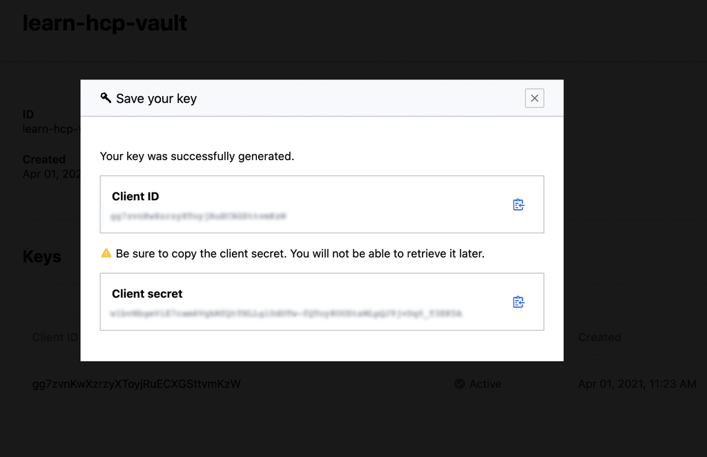

11. Copy the **Client ID**.
12. Open a new terminal.
13. Export an environment variable for the `HCP_CLIENT_ID`.

    ```
    $ export HCP_CLIENT_ID=<client id value previously copied>
    ```

14. Return to the HCP Portal and copy the **Client secret**.
15. Return to the terminal and export an environment variable for the `HCP_CLIENT_SECRET`.

    ```
    $ export HCP_CLIENT_SECRET=<client secret value previously copied>
    ```

### Clone Terraform configuration

Clone the learn-configure-hcp-vault-terraform repository to get the necessary Terraform configuration for the tutorial.

1. Change into your preferred working directory and clone the repository.

   ```
   $ git clone https://github.com/hashicorp-education/learn-configure-hcp-vault-terraform
   ```

2. Change into the directory containing the Terraform configuration for this tutorial.

   ```
   $ cd learn-configure-hcp-vault-terraform
   ```

3. Verify that you are in the correct directory before proceeding.

   ```
   $ ls -1
   config
   LICENSE
   README.md
   hcpvault.tf
   outputs.tf
   vault-config
   provider.tf
   variables.tf
   ```

   Run the commands for this tutorial from this directory.

### Deploy an HCP Vault cluster

This tutorial requires an HCP Vault cluster to demonstrate the ability to manage the cluster lifecycle with Terraform.

1. Initialize Terraform.

   ```
   $ terraform init

   Initializing the backend...

   Initializing provider plugins...
   ...snip...

   Terraform has been successfully initialized!
   ```

2. Deploy the HCP Vault cluster using the `terraform apply` command.

   ```
   $ terraform apply -auto-approve

   Terraform used the selected providers to generate the following execution plan. Resource actions
   are indicated with the following symbols:
     + create
    <= read (data resources)

   Terraform will perform the following actions:

   Outputs:

   namespace = "admin"
   primary_token = <sensitive>
   primary_vault_public_endpoint_url = "https://vault-cluster-primary-public-vault-gr33d8647.z1.hashicorp.cloud:8200"
   ```

   The Terraform configuration deploys an HVN and HCP Vault cluster.

### Add HCP Vault Dedicated environment variables

Set up your local environment to authenticate with the HCP Vault cluster. By using the example Terraform configuration, you can get the required values from the Terraform output.

1. Export the Terraform output as environment variables. This allows the Vault CLI and Terraform to authenticate with the HCP Vault cluster.

   ```
   $ export VAULT_ADDR=$(terraform output -raw primary_vault_public_endpoint_url) \
       VAULT_TOKEN=$(terraform output -raw primary_token) \
       VAULT_NAMESPACE=admin
   ```

2. Verify you can run commands for the HCP Vault cluster.

   ```
   $ vault auth list
   Path      Type        Accessor                  Description                Version
   ----      ----        --------                  -----------                -------
   token/    ns_token    auth_ns_token_d5df0532    token based credentials    n/a
   ```

### Deploy sample Vault configuration

When the cluster creation completes, apply the example configuration.

1. Initialize Terraform and deploy the configuration.

   ```
   $ terraform -chdir=config/ init && \
       terraform -chdir=config/ apply -auto-approve
   ```

   **Example output:**

   ```
   Terraform used the selected providers to generate the following execution plan. Resource actions are indicated with the following symbols:
     + create

   Terraform will perform the following actions:

     # vault_auth_backend.userpass will be created
     + resource "vault_auth_backend" "userpass" {
         + accessor = (known after apply)
         + id       = (known after apply)
         + path     = (known after apply)
         + tune     = (known after apply)
         + type     = "userpass"
       }

   ...snip...

   vault_generic_secret.student_api_key: Creation complete after 0s [id=api-credentials/student/api-key]
   vault_generic_secret.golden: Creation complete after 0s [id=api-credentials/student/golden]
   vault_generic_secret.api-wizard-service: Creation complete after 0s [id=api-credentials/admin/api-wizard]

   Apply complete! Resources: 11 added, 0 changed, 0 destroyed.
   ```

2. Run `vault auth list` again to see the changes to your Vault cluster.

   ```
   $ vault auth list
   Path         Type        Accessor                  Description                Version
   ----         ----        --------                  -----------                -------
   token/       ns_token    auth_ns_token_d5df0532    token based credentials    n/a
   userpass/    userpass    auth_userpass_e9fd24d9    n/a                        n/a
   ```

## Review Terraform configuration

The Terraform configuration used by this tutorial are consistent with the [Deploy HCP Vault with Terraform](https://developer.hashicorp.com/vault/tutorials/manage-hcp-vault-dedicated/deploy-hcp-vault-terraform) and [Configure HCP Vault with Terraform](https://developer.hashicorp.com/vault/tutorials/manage-hcp-vault-dedicated/configure-hcp-vault-terraform) tutorials. If you are not familiar with deploying HCP Vault, or configuring HCP Vault with Terraform, review those tutorials.

1. Review the cluster tier settings in `variables.tf`.

   ```
   $ grep -A 4 tier variables.tf

   variable "tier" {
     description = "Tier of the HCP Vault cluster."
     type        = string
     default     = "dev"
   }
   ```

   The Terraform configuration sets the default HCP Vault cluster tier to `dev`. The development tier is useful for isolated developer environments, testing Vault features, and performing initial configuration while the cluster is not responding to workload requests.

   To run a production grade HCP Vault cluster, you can scale the cluster up from the development tier to either the [essentials or standard tier](https://developer.hashicorp.com/hcp/docs/vault/get-started/deployment-considerations/tiers-and-features).

   Note

   Once you scale a cluster up from the development tier, you cannot scale it back down to the development tier.
2. Review the cluster configuration in `hcpvault.tf`.

   ```
   $ cat hcpvault.tf

   resource "time_sleep" "wait_30_primary" {
     depends_on = [hcp_vault_cluster.primary_cluster]
     create_duration = "30s"
   }

   resource "hcp_hvn" "primary_cluster_hvn" {
     hvn_id         = var.primary_cluster_hvn
     cloud_provider = var.cloud_provider
     region         = var.primary_region
     cidr_block     = var.primary_cluster_hvn_cidr
   }

   resource "hcp_vault_cluster" "primary_cluster" {
     hvn_id     = hcp_hvn.primary_cluster_hvn.hvn_id
     cluster_id = var.primary_cluster_id
     tier       = var.tier
     public_endpoint = true
   }

   resource "hcp_vault_cluster_admin_token" "primary_cluster_token" {
     cluster_id      = var.primary_cluster_id
     depends_on      = [time_sleep.wait_30_primary]
   }
   ```

   The `hcpvault.tf` configuration deploys a single HCP Vault cluster, and generates an admin token for the cluster.

   **Challenge question:**

   Q: What tier will Terraform use for the HCP Vault cluster?

   A: Terraform deploys a development tier cluster, using the variable `var.tier` set to a default value of `dev` in the `variables.tf` configuration.

## Scale up the HCP Vault Dedicated cluster

With HCP Vault, you can scale your cluster with a change to the `variables.tf` file and re-applying the configuration. The underlying infrastructure and associated management of that infrastructure is handled by HashiCorp.

1. Change the tier from `dev` to `plus_small` in the `variables.tf` file.

   ```
   $ sed -ibak "s/dev/plus_small/g" variables.tf
   ```

   There are different ways to change the tier through Terraform. For temporary changes, you can override the default variable value during apply by passing `-var="tier=plus_small"` or create a `terraform.tfvars` file. However, since the Terraform configuration in your version control system (VCS) is the source of truth for your HCP Vault cluster, this tutorial demonstrates changing the value directly in the Terraform configuration.

   Changing the Terraform configuration provides several benefits:
   - **Source of truth**: Your running infrastructure matches your configuration files
   - **Code review**: Team members can review and approve infrastructure changes
   - **Automation**: CI/CD workflows can automatically trigger an apply when you commit changes
   - **Auditable**: All changes tracked in version control history

   Using `-var` flags for permanent infrastructure changes creates drift between your configuration files and actual infrastructure state.

   Note

   Due to a recent licensing update, `plus` tiers in the Terraform provider for HCP map to the HCP Vault standard tier, and `standard` tiers map to the HCP Vault essentials tier.
2. Verify the updated configuration.

   ```
   $ cat variables.tf | grep -A 4 tier

   variable "tier" {
     description = "Tier of the HCP Vault cluster."
     type        = string
     default     = "plus_small"
   }
   ```

3. Re-apply the configuration to change the tier.

   ```
   $ terraform apply -auto-approve

   Terraform used the selected providers to generate the following execution plan. Resource actions are indicated with the following symbols:
     ~ update in-place

   Terraform will perform the following actions:

     # hcp_vault_cluster.primary_cluster will be updated in-place
     ~ resource "hcp_vault_cluster" "primary_cluster" {
           id                         = "/project/a2c4e6g-8920-4714-ba99-0242ac11000e/hashicorp.vault.cluster/vault-cluster-primary"
         ~ tier                       = "DEV" -> "plus_small"
           # (14 unchanged attributes hidden)
       }

   Plan: 0 to add, 1 to change, 0 to destroy.
   ...snip...
   hcp_vault_cluster.primary_cluster: Modifications complete after 30m36s [id=/project/70d220a8-c83e-47bf-99a9-7a2ce0f98156/hashicorp.vault.cluster/vault-cluster-primary]

   Apply complete! Resources: 0 added, 1 changed, 0 destroyed.

   Outputs:

   namespace = "admin"
   primary_token = <sensitive>
   primary_vault_public_endpoint_url = "https://vault-cluster-primary-public-vault-5c448d42.723e7ba5.z1.hashicorp.cloud:8200"
   ```

   The output shows that the cluster `will be updated in-place`. You do not need to replace or stop the cluster to change the clusters tier or size.

## Access the HCP Vault Dedicated cluster

One of the benefits of running your Vault cluster on HCP is HashiCorp manages most of the infrastructure related maintenance. While your cluster is scaling, applications that rely on Vault can still access Vault resources.

1. Log into the [HCP Portal](https://portal.cloud.hashicorp.com/) and navigate to the Vault clusters list while Terraform is upgrading the cluster.
2. Observe that your cluster is an `Updating` state.

[figure not shown]

3. Click `vault-cluster-primary` to access details about the cluster.
4. Information about the cluster is still available while the upgrade is in process.
5. Click the **Public** link under **Cluster URLs** to copy the URL.
6. Open a new browser tab and navigate to the copied URL. Vault is still accessible even during the upgrade.
7. Click the **Method** pull down menu and select **Username**.
8. Log in as `admin` with the password `superS3cret!`.
9. Navigate to **Secrets** and click **api-credentials**.

Even though the HCP is upgrading the cluster, Vault is still available and accessible for incoming requests.

## Add performance replication

You have scaled your cluster up from the **dev** tier to the **standard** tier to support increased Vault utilization.

To meet the demands of your applications running in the west region, you need to create a cluster in the west region by enabling performance replication.

Note

Performance replication is available on all standard tier HCP Vault Dedicated clusters.

Adding performance replication to an existing cluster is similar to creating a new HCP Vault cluster using Terraform. You will need to:

- Define an HVN in the same cloud provider, but in a different region
- Define a new HCP Vault cluster
- Associate the new cluster with your primary cluster
1. Add the required values for the new replica cluster to the `variables.tf` file.

   ```
   $ cat >> variables.tf <<EOF

   variable "secondary_region" {
     description = "The region of the secondary cluster HCP HVN and Vault cluster."
     type        = string
     default     = "us-west-2"
   }

   variable "secondary_cluster_hvn" {
     description = "The ID of the HCP HVN."
     type        = string
     default     = "hvn-aws-us-west-2"
   }

   variable "secondary_cluster_hvn_cidr" {
     description = "The CIDR range of the HCP HVN."
     type        = string
     default     = "172.24.16.0/20"
   }

   variable "secondary_cluster_id" {
     description = "The ID of the Vault Dedicated cluster."
     type        = string
     default     = "vault-cluster-secondary"
   }
   EOF
   ```

2. Review the `variables.tf` file.

   ```
   $ cat variables.tf

   variable "cloud_provider" {
     description = "The cloud provider of the HCP HVN and Vault cluster."
     type        = string
     default     = "aws"
   }

   variable "primary_region" {
     description = "The region of the primary cluster HCP HVN and Vault cluster."
     type        = string
     default     = "us-east-1"
   }

   variable "primary_cluster_hvn" {
     description = "The ID of the HCP HVN."
     type        = string
     default     = "hvn-aws-us-east-1"
   }

   variable "primary_cluster_hvn_cidr" {
     description = "The CIDR range of the HCP HVN."
     type        = string
     default     = "172.25.16.0/20"
   }

   variable "primary_cluster_id" {
     description = "The ID of the Vault Dedicated cluster."
     type        = string
     default     = "vault-cluster-primary"
   }

   variable "secondary_cluster_hvn" {
     description = "The ID of the HCP HVN."
     type        = string
     default     = "hvn-aws-us-west-2"
   }

   variable "secondary_cluster_hvn_cidr" {
     description = "The CIDR range of the HCP HVN."
     type        = string
     default     = "172.24.16.0/20"
   }

   variable "secondary_cluster_id" {
     description = "The ID of the Vault Dedicated cluster."
     type        = string
     default     = "vault-cluster-secondary"
   }

   variable "secondary_region" {
     description = "The region of the secondary cluster HCP HVN and Vault cluster."
     type        = string
     default     = "us-west-2"
   }
   ```

   Terraform now has the variables that support creating the performance replica secondary cluster in the `variables.tf` file.
3. Update `hcpvault.tf` to add the required resource blocks for the new cluster.

   ```
   $ cat >> hcpvault.tf <<EOF

   resource "time_sleep" "wait_30_secondary" {
     depends_on = [hcp_vault_cluster.secondary_cluster]
     create_duration = "30s"
   }

   resource "hcp_hvn" "secondary_cluster_hvn" {
     hvn_id         = var.secondary_cluster_hvn
     cloud_provider = var.cloud_provider
     region         = var.secondary_region
     cidr_block     = var.secondary_cluster_hvn_cidr
   }

   resource "hcp_vault_cluster" "secondary_cluster" {
     hvn_id          = hcp_hvn.secondary_cluster_hvn.hvn_id
     cluster_id      = var.secondary_cluster_id
     tier            = var.tier
     primary_link    = hcp_vault_cluster.primary_cluster.self_link
     public_endpoint = true
   }

   resource "hcp_vault_cluster_admin_token" "secondary_cluster_token" {
     cluster_id      = var.secondary_cluster_id
     depends_on      = [time_sleep.wait_30_secondary]
   }
   EOF
   ```

4. Review the `hcpvault.tf` file.

   ```
   $ cat hcpvault.tf

   resource "hcp_hvn" "primary_cluster_hvn" {
     hvn_id         = var.primary_cluster_hvn
     cloud_provider = var.cloud_provider
     region         = var.primary_region
     cidr_block     = var.primary_cluster_hvn_cidr
   }

   resource "hcp_vault_cluster" "primary_cluster" {
     hvn_id     = hcp_hvn.primary_cluster_hvn.hvn_id
     cluster_id = var.primary_cluster_id
     tier       = var.tier
     public_endpoint = true
   }

   resource "hcp_vault_cluster_admin_token" "primary_cluster_token" {
     cluster_id      = var.primary_cluster_id
     depends_on      = [time_sleep.wait_30_seconds]
   }

   resource "hcp_hvn" "secondary_cluster_hvn" {
     hvn_id         = var.secondary_cluster_hvn
     cloud_provider = var.cloud_provider
     region         = var.secondary_region
     cidr_block     = var.secondary_cluster_hvn_cidr
   }

   resource "hcp_vault_cluster" "secondary_cluster" {
     hvn_id          = hcp_hvn.secondary_cluster_hvn.hvn_id
     cluster_id      = var.secondary_cluster_id
     tier            = var.tier
     primary_link    = hcp_vault_cluster.primary_cluster.self_link
     public_endpoint = true
   }

   The Terraform configuration for HCP Vault now includes the resources to create the new cluster. Terraform associates the performance replica cluster using the `primary_link` parameter to associate the new cluster with the primary cluster.
5. Add an output for the new clusters URL.

   ```
   $ cat >> outputs.tf <<EOF

   output "secondary_vault_public_endpoint_url" {
     value       = hcp_vault_cluster.secondary_cluster.vault_public_endpoint_url
     description = "The public IP address of the secondary cluster."
   }
   EOF
   ```

6. Create the new cluster by re-running `terraform apply`.

   ```
   $ terraform apply -auto-approve

   ...snip...
   hcp_hvn.primary_cluster_hvn: Refreshing state... [id=/project/11eb3a47-8920-4714-ba99-0242ac11000e/hashicorp.network.hvn/hvn-aws-us-east-1]
   hcp_vault_cluster.primary_cluster: Refreshing state... [id=/project/11eb3a47-8920-4714-ba99-0242ac11000e/hashicorp.vault.cluster/vault-cluster-primary]
   time_sleep.wait_30_primary: Refreshing state... [id=2022-06-07T17:11:47Z]
   hcp_vault_cluster_admin_token.primary_cluster_token: Refreshing state... [id=/project/11eb3a47-8920-4714-ba99-0242ac11000e/hashicorp.vault.cluster/vault-cluster-primary/token]

   Terraform used the selected providers to generate the following execution plan. Resource actions are indicated with the following symbols:
     + create

   Terraform will perform the following actions:

     # hcp_hvn.secondary_cluster_hvn will be created
     + resource "hcp_hvn" "secondary_cluster_hvn" {

   ...snip...

   hcp_vault_cluster.secondary_cluster: Still creating... [17m1s elapsed]
   hcp_vault_cluster.secondary_cluster: Creation complete after 17m8s [id=/project/11eb3a47-8920-4714-ba99-0242ac11000e/hashicorp.vault.cluster/vault-cluster-secondary]
   time_sleep.wait_30_secondary: Creating...
   time_sleep.wait_30_secondary: Still creating... [10s elapsed]
   time_sleep.wait_30_secondary: Still creating... [20s elapsed]
   time_sleep.wait_30_secondary: Creation complete after 30s [id=2022-06-07T21:37:16Z]
   hcp_vault_cluster_admin_token.secondary_cluster_token: Creating...
   hcp_vault_cluster_admin_token.secondary_cluster_token: Creation complete after 3s [id=/project/11eb3a47-8920-4714-ba99-0242ac11000e/hashicorp.vault.cluster/vault-cluster-secondary/token]

   Apply complete! Resources: 4 added, 0 changed, 0 destroyed.

   Outputs:

   namespace = "admin"
   primary_token = <sensitive>
   primary_vault_public_endpoint_url = "https://vault-cluster-primary-public-vault-f0694e72.5f8f89a2.z1.hashicorp.cloud:8200"
   secondary_vault_public_endpoint_url = "https://vault-cluster-secondary-public-vault-d9915240.da3e83c2.z1.hashicorp.cloud:8200"
   ```

7. Log into the [HCP Portal](https://portal.cloud.hashicorp.com/) and navigate to the Vault clusters list.

[figure not shown]

   The HCP Portal displays both the primary and secondary cluster.
8. Unset the `VAULT_TOKEN` environment variable used to authenticate with the primary cluster.

   ```
   $ unset VAULT_TOKEN
   ```

9. Log into the secondary cluster using the Vault CLI.

   ```
   $ vault login \
      -address=$(terraform output -json | jq -r '.secondary_vault_public_endpoint_url.value') \
      -method=userpass \
      username=admin \
      password=superS3cret!
   ```

10. Verify the status of the secondary Vault cluster.

    ```
    $ vault status \
       -address=$(terraform output -json | jq -r '.secondary_vault_public_endpoint_url.value')
    ```

    **Example output:**

    ```
    Key                                    Value
    ---                                    -----
    Seal Type                              awskms
    Recovery Seal Type                     shamir
    Initialized                            true
    Sealed                                 false
    Total Recovery Shares                  1
    Threshold                              1
    Version                                1.21.2+ent
    Build Date                             2026-01-06T16:58:57Z
    Storage Type                           raft
    Cluster Name                           b9ad0b7b-9711-4df6-80be-54d03e41077e
    Cluster ID                             0eacd8d6-134b-a93d-f766-1b77b375dbdf
    Removed From Cluster                   false
    HA Enabled                             true
    HA Cluster                             https://172.24.24.12:8201
    HA Mode                                standby
    Active Node Address                    https://node-1-2.vault-cluster-secondary-private-vault-d0339141.3fd678d8.z1.hashicorp.cloud:8202
    Performance Standby Node               true
    Performance Standby Last Remote WAL    1154
    Raft Committed Index                   3948
    Raft Applied Index                     3948
    ```

    You can verify this is the secondary cluster because the IP address is part of the address space defined for the secondary cluster HVN.
11. View available secrets engines.

    ```
    $ vault secrets list \
       -address=$(terraform output -json | jq -r '.secondary_vault_public_endpoint_url.value')
    ```

    **Example output:**

    ```
    Path                Type            Accessor                 Description
    ----                ----            --------                 -----------
    api-credentials/    kv              kv_e80f580b              n/a
    cubbyhole/          ns_cubbyhole    ns_cubbyhole_ebc1e938    per-token private secret storage
    identity/           ns_identity     ns_identity_647c3433     identity store
    sys/                ns_system       ns_system_b24fbdca       system endpoints used for control, policy and debugging
    transit/            transit         transit_d83dca00         n/a
    ```

    All secrets engines were replicated from the primary cluster.

## Add a path filter

Now that you have deployed performance replication, you need to remove the `transit` secrets engine from the secondary cluster.

You add a path filter that denies a specific path from replication to the secondary cluster.

1. Add the `paths_filter` parameter to the secondary clusters resource block in `hcpvault.tf`.

   ```
   $ sed -ibak '/primary_link/a\
     paths_filter    = ["transit"]
    ' hcpvault.tf
   ```

2. Re-apply the Terraform configuration to prevent Vault from replicating the `transit` secrets engine to the secondary cluster.

   ```
   $ terraform apply -auto-approve
   ```

3. Verify that the `transit` secrets engine is no longer available on the secondary cluster.

   ```
   $ vault secrets list \
      -address=$(terraform output -json | jq -r '.secondary_vault_public_endpoint_url.value')
   ```

   **Example output:**

   ```
   Path                Type            Accessor                 Description
   ----                ----            --------                 -----------
   api-credentials/    kv              kv_e80f580b              n/a
   cubbyhole/          ns_cubbyhole    ns_cubbyhole_ebc1e938    per-token private secret storage
   identity/           ns_identity     ns_identity_647c3433     identity store
   sys/                ns_system       ns_system_b24fbdca       system endpoints used for control, policy and debugging
   ```

   The `transit` secrets engine is no longer listed.

## Disable performance replication and scale down the cluster

You have scaled your HCP Vault cluster from the `dev` tier to the `plus` tier and enabled performance replication. During peak business hours your applications have the necessary access to HCP Vault to meet your SLOs.

To help manage cost, you want to remove the secondary cluster and scale down your cluster during non-peak hours.

Removing performance replication requires removing the resources block for the secondary cluster. Similarly, scaling the cluster down to a smaller tier requires changing the tier value in `variables.tf`.

1. Remove the secondary cluster resources from `hcpvault.tf`.

   ```
   $ sed -ibak '24,$ d' hcpvault.tf
   ```

2. Remove the secondary cluster URL from outputs.tf

   ```
   $ sed -ibak '16,$ d' outputs.tf
   ```

3. Change the tier from `plus_small` to `standard_small`.

   ```
   $ sed -ibak "s/plus_small/standard_small/g" variables.tf
   ```

4. Re-apply the Terraform configuration.

   ```
   $ terraform apply -auto-approve
   ```

   **Example output:**

   ```
   time_sleep.wait_30_secondary: Refreshing state... [id=2022-06-08T18:23:13Z]
   hcp_vault_cluster_admin_token.secondary_cluster_token: Refreshing state... [id=/project/11eb3a47-8920-4714-ba99-0242ac11000e/hashicorp.vault.cluster/vault-cluster-secondary/token]
   hcp_hvn.secondary_cluster_hvn: Refreshing state... [id=/project/11eb3a47-8920-4714-ba99-0242ac11000e/hashicorp.network.hvn/hvn-aws-us-west-2]
   hcp_hvn.primary_cluster_hvn: Refreshing state... [id=/project/11eb3a47-8920-4714-ba99-0242ac11000e/hashicorp.network.hvn/hvn-aws-us-east-1]
   hcp_vault_cluster.secondary_cluster: Refreshing state... [id=/project/11eb3a47-8920-4714-ba99-0242ac11000e/hashicorp.vault.cluster/vault-cluster-secondary]
   hcp_vault_cluster.primary_cluster: Refreshing state... [id=/project/11eb3a47-8920-4714-ba99-0242ac11000e/hashicorp.vault.cluster/vault-cluster-primary]
   time_sleep.wait_30_primary: Refreshing state... [id=2022-06-08T13:54:09Z]
   hcp_vault_cluster_admin_token.primary_cluster_token: Refreshing state... [id=/project/11eb3a47-8920-4714-ba99-0242ac11000e/hashicorp.vault.cluster/vault-cluster-primary/token]

   Terraform used the selected providers to generate the following execution plan. Resource actions are indicated with the following symbols:
     ~ update in-place
     - destroy

   Terraform will perform the following actions:

     # hcp_hvn.secondary_cluster_hvn will be destroyed
     # (because hcp_hvn.secondary_cluster_hvn is not in configuration)

   ...snip...

   hcp_vault_cluster.primary_cluster: Still modifying... [id=/project/11eb3a47-8920-4714-ba99-0242ac...rp.vault.cluster/vault-cluster-primary, 15m21s elapsed]
   hcp_vault_cluster.primary_cluster: Modifications complete after 15m27s [id=/project/11eb3a47-8920-4714-ba99-0242ac11000e/hashicorp.vault.cluster/vault-cluster-primary]

   Apply complete! Resources: 0 added, 1 changed, 4 destroyed.

   Outputs:

   namespace = "admin"
   primary_token = <sensitive>
   primary_vault_public_endpoint_url = "https://vault-cluster-primary-public-vault-d7a8ff49.edd3051f.z1.hashicorp.cloud:8200"
   ```

5. Log into the [HCP Portal](https://portal.cloud.hashicorp.com/) and navigate to the Vault clusters list. Terraform removed the secondary cluster and the cluster scaled down from `plus_small` to `standard_small`.

## Summary

By using simple, modular, and composable infrastructure as code with Terraform, you can manage the lifecycle of your HCP Vault clusters.

## Clean up

Here are the steps you need to clean up the scenario content from your local environment.

1. Delete the HCP Vault configuration.

   ```
   $ VAULT_TOKEN=$(terraform output -raw primary_token) terraform -chdir=config/ destroy -auto-approve
   ```

2. Delete the HCP Vault cluster instance and HVN.

   ```
   $ terraform destroy -auto-approve
   ```

3. Unset the environment variables.

   ```
   $ unset VAULT_ADDR VAULT_TOKEN VAULT_NAMESPACE
   ```

## Help and reference

- [Migration Strategies and Considerations Guidelines](https://developer.hashicorp.com/hcp/docs/vault/migrate-to-hcp)
- [Terraform provider for Vault](https://registry.terraform.io/providers/hashicorp/vault/latest/docs)
- [Terraform provider for HCP](https://registry.terraform.io/providers/hashicorp/hcp/latest/docs)

Previous

Codify Vault Enterprise with Terraform

Next

Deploy Consul and Vault on Kubernetes

  Manage HCP Vault Dedicated

  Terraform for HCP Vault Dedicated

  HashiCorp product integrations

  Vault can manage secrets associated with other HashiCorp products.